# Co-occurrence Analysis

Nicholas J. Gotelli, Edmund M. Hart, Aaron M. Ellison

8 March 2015

```r
library(EcoSimR)    # load EcoSimR library
set.seed(56)        # for reproducible results
```

## Theory

Diamond (1975) proposed that communities are comprised of species whose occurrences (and morphology) are shaped primarily by interspecific competition for shared resources. When “replicated” communities such as island assemblages are compared, recurrent patterns emerge that reflect this competition, which Diamond (1975) designated as “assembly rules”. Two such rules are

- Of the 2<sup>*S*</sup> - 1 possible species combinations that can be can be formed from a set of *S* species, some combinations will never be found in nature because they represent “forbidden combinations” that do not persist because of interspecific interactions.
- Particular pairs of species may never co-occur, so that replicate communities will contain species *A* or species *B*, but never both together. These “checkerboard pairs” reflect interspecific competition and priority effects that can allow one species to exclude a later arrival.

Connor and Simberloff (1979) challenged these interpretations by asking what patterns of co-occurrence would be expected by in the absence of such interactions. They introduced an important class of null models to ecology, and triggered a debate that continues to this day (Sanderson et al. 2010, Connor et al. 2013).

This module of EcoSimR includes metrics and algorithms for testing for patterns of community co-occurrence. This literature remains controversial and continues to evolve. EcoSimR contains a variety of randomization algorithms that were developed for co-occurrence analyses, but may be applicable to other kinds of problems. Not all of these algorithms and metrics are recommended, because most of them are vulnerable to Type I statistical errors (incorrectly rejecting a null hypothesis for a purely random data set). We have recommended particular tools based on previous benchmark analyses with artificial data sets (Gotelli 2000).

## Data

The data for co-occurrence analysis consist of a binary presence-absence matrix in which each row is a species, each column is a site (or sample), and the entries represent the presence (1) or absence (0) of a species in a site. `NA` values and negative values are not allowed. Positive real numbers should be converted to 1s before analysis. As in other EcoSimR modules, these data should be organized into a data frame, with optional species and/or site names in the first column and/or first row. For one of the algorithms, `sim10` users can supply an additional vector of row and/or column weights, which would reflect the relative occurrence probability of the different species (row weights) and/or the relative suitability of the different sites for species occurrence (column weights).

The sample data set for this analysis is `dataWiFinches`, the occurrence records for the 17 species of finches (Fringillidae) recorded from the 19 major islands of the West Indies (Gotelli and Abele 1982).

Occurrence matrix of West Indies finches. Data from Gotelli & Abele (1982)

| Species | Cuba | Hispaniola | Jamaica | Puerto_Rico | Guadeloupe |
| --- | --- | --- | --- | --- | --- |
| Carduelis_dominicensis | 0 | 1 | 0 | 0 | 0 |
| Loxia_leucoptera | 0 | 1 | 0 | 0 | 0 |
| Volatinia_jacarina | 0 | 0 | 0 | 0 | 0 |
| Sporophila_nigricollis | 0 | 0 | 0 | 0 | 0 |
| Melopyrrha_nigra | 1 | 0 | 0 | 0 | 0 |
| Loxigilla_portoricensis | 0 | 0 | 0 | 1 | 0 |
| Loxigilla_violacea | 0 | 1 | 1 | 0 | 0 |
| Loxigilla_noxis | 0 | 0 | 0 | 0 | 1 |
| Melanospiza_richardsoni | 0 | 0 | 0 | 0 | 0 |
| Tiara_olivacea | 1 | 1 | 1 | 1 | 0 |
| Tiara_bicolor | 0 | 1 | 1 | 1 | 1 |
| Tiara_canora | 1 | 0 | 0 | 0 | 0 |
| Loxipasser_anoxanthus | 0 | 0 | 1 | 0 | 0 |
| Saltator_albicollis | 0 | 0 | 0 | 0 | 1 |
| Torreornis_inexpectata | 1 | 0 | 0 | 0 | 0 |
| Ammodramus_savannarum | 0 | 1 | 1 | 1 | 0 |
| Zonotrichia_capensis | 0 | 1 | 0 | 0 | 0 |

## Metrics

EcoSimR offers 4 basic metrics for co-occurrence analysis. Two of these (`v_ratio` and `c_score`) quantify the average degree of co-occurrence (which can range from segregated through random to aggregated) for all possible pairs of species. The other two (`checker` and `species_combo`) count the number of checkerboard species pairs and the number of unique species combinations in the matrix, which directly address two of Diamond’s (1975) original assembly rules.

The V-ratio (Variance ratio) measures the average covariance in association between all possible species pairs (Schluter 1984). It is the ratio of the variance of the column sums to the sum of the column variances. In a random matrix, this ratio should be close to 1.0. In an aggregated matrix, the V-ratio will be much larger than 1.0, and in a segregated matrix, the V-ratio will be much smaller than 1.0. The V-ratio will equal the minimum value of 0.0 when all sites contain identical numbers of species. The V-ratio depends entirely on the row and column sums of the matrix, so it cannot be used with the `sim9` algorithm, in which the row and column sums are the same in the original and all simulated matrices.

The C-score (Checkerboard score; Stone and Roberts 1990) measures association between species pairs in a slightly different way. Rather than using the average covariance between each species pair, the C-score is based on the number of checkerboard units. The C-score for species pair *AB* is calculated as

$C_{AB} = (R_A - SS)(R_B -SS)$

where *R<sub>A</sub>* is the row total for species *A*, *R<sub>B</sub>* is the row total for species *B*, and *SS* is the number of sites that contain both *A* and *B*. Thus, for any particular species pair, the C-score is a numerical index that ranges from a minimum of 0 (maximally aggregated) to a maximum of *R<sub>A</sub>R<sub>B</sub>* (maximally segregated with no shared sites).

The higher the C-score, the less co-occurrence, on average, between all of the species pairs in the matrix. A relatively large C-score indicates a more segregated matrix, and a relatively small C-score indicates a more aggregated matrix. However, within any matrix, there will be a mixture of segregated, aggregated, and random species pairs, all of which contribute to the observed C-score (Gotelli and Ulrich 2010). When used with `sim9`, the C-score measures co-occurrence patterns above and beyond those determined by the row and column sums of the matrix, so the information (and null model) is different from what is provided by the V-ratio.

Although `c_score` is an average for all pairs of species in the matrix, EcoSimR will also allow for analyses of the variance of the C-score (`c_score_var`), and the skewness of the C-score (`c_score_skew`). These metrics respectively quantify the degree of heterogeneity in the C-scores of the different species, and the presence of asymmetrically large (or small) outlier pairs that are highly segregated (positive skewness) or highly aggregated (negative skewness). These measures have not been well-explored so far, but they do provide a nice complement to the results for `c_score`.

## Algorithms

EcoSimR allows for 3 basic strategies to randomize a presence-absence matrix based on the marginal row and column totals of the data matrix.

- margin totals allowed to vary randomly and equiprobably (“Equiprobable”)
- margin totals allowed to vary randomly, with probabilities proportional to the margin totals in the original matrix (“Proportional”)
- marginal totals fixed and identical to the margin totals in the original matrix (“fixed-fixed”).

Applying these 3 strategies to both row and column marginals yields a set of 9 possible null model algorithms (`sim1` to `sim9`). A tenth algorithm is to supply vectors of external weights for rows and columns. These vectors represent independent data about the relative occurrence potential of the different species (row weights) and/or the relative suitability of the different sites for species occupancy (column weights).

Randomization algorithms for co-occurrence (Gotelli 2000).

| Algorithm | RowSums | ColSums | Notes |
| --- | --- | --- | --- |
| sim1 | Equiprobable | Equiprobable | not recommended |
| sim2 | Fixed | Equiprobable | recommended |
| sim3 | Equiprobable | Fixed | not recommended |
| sim4 | Fixed | Proportional | not recommended |
| sim5 | Proportional | Fixed | not recommended |
| sim6 | Equiprobable | Proportional | not recommended |
| sim7 | Proportional | Equiprobable | not recommended |
| sim8 | Proportional | Proportional | not recommended |
| sim9 | Fixed | Fixed | recommended (DEFAULT) |
| sim10 | External Weights | External Weights | recommended |

- `sim9` This algorithm preserves the observed row and column totals, conforming to the field biologist’s intuition that there are marked differences in the commonness and rarity of species, and variation in species richness among sites. This algorithm measures non-random above and beyond those introduced by heterogeneity in the marginal totals. It is conservative, but it performs fairly well with a variety of different kinds of random matrices. This is the default algorithm for co-occurrence in EcoSimR.[^1]
- `sim2` By reshuffling elements within each row of the matrix, `sim2` preserves the differences among species in incidence, but assumes that all sites are equiprobable. This algorithm is typically used with `v_ratio`, which often yields aggregated or random patterns (Schluter 1984). If the column totals of the matrix differ considerably (e.g., sites are islands that differ greatly in area), when the `c-score` is used with `sim2` it may yield a random or an aggregated pattern, but when it is used with `sim9`, it may yield a segregated pattern. In such a case, the aggregated pattern of a few sites with a great number of species would be improbable with `sim2`, which assumes sites are equiprobable.
- `sim10` This algorithm is also recommended because it offers the greatest chance to inject ecological realism into the model because it incorporates information beyond what is contained in the data matrix itself. Sites can be conditioned on resources, area, or isolation, and species can be conditioned on body size, population size, or geographic range placement (Jenkins 2006, Gotelli et al. 2010). The only caveat is that, if there is too much heterogeneity in the species weights, the simulated matrices may contain empty rows or columns.

## Graphics

The co-occurrence module offers three graphic outputs. `plot(myModel, type="hist")` generates a standard histogram of simulated metric values (blue bars) based on the selected algorithm and metric. The vertical red line indicates the observed metric for the original data, the pair of vertical long-dash lines indicate the 95% one-tailed cutpoints, and the short-dash lines indicate the 95% two-tailed cutpoints. The latter would constitute a proper 95% confidence interval for the null distribution. Note that these intervals are not based on a normal or other parametric distribution. Instead, they are always estimated directly from the histogram, which means they could be asymmetric, and will be sensitive to the number of replicates used.

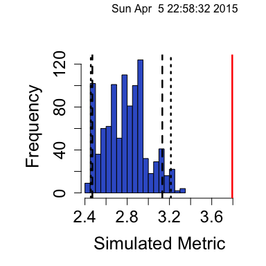

The second graphic, `plot(myModel,type="cooc")`, illustrates graphically one simulated matrix (left panel, blue) and the original data matrix (right panel, red). The data are portrayed as a grid with colored cells (species presences) and empty cells (species absences). A careful comparison of these two matrices should confirm the behavior of the chosen randomization algorithm.

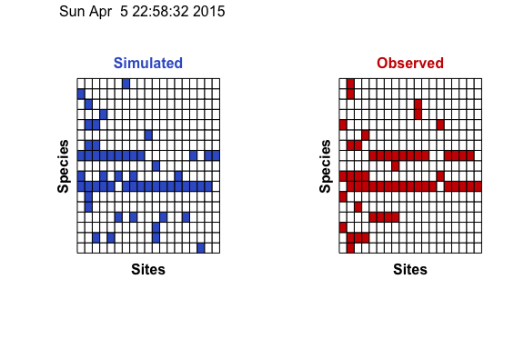

If the algorithm is `sim9`, a third graphic option is available in the co-occurrence module. in this case, `plot(myModel,type="burn_in")` will show the trace value for the burn in period of the Markov chain. This can be useful for determining how many burn-in iterations are necessary to ensure that the distribution is approximately stationary. The plot shows the number of burn-in iterations on the *x*-axis and the metric value on the *y*-axis. The observed index is shown as a horizontal red line, the simulated values are shown as a blue line, and a grey spline curve is fit through the simulated sequence. For example, the default analysis uses a burn-in of 500 interations, and generates this plot:

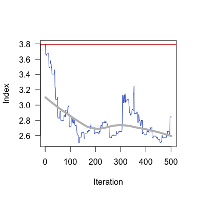

## Defaults

```r
speciesData          # user must supply a data frame; speciesData=dataWiFinches for default run
algo = "sim9"        # randomize occurrences but preserve observed row and columns sums
metric = "c_score"   # Stone and Roberts (1990) C-score
nReps = 1000         # number of null assemblage created
rowNames=TRUE        # reads speciesData as a data frame wtih row labels in the first column
saveSeed=FALSE       # if TRUE, saves random number seed
burn_in=500          # number of burn-in iterations for sim9
algoOpts=list()      # list of other specific options for the algorithm (used for sim10)
metricOpts=list()    # list of other specific options for the metric
suppressProg= FALSE  # suppress printing of progress bar (for creating markdown files)
```

## Examples

```r
# run default settings and show all output
myModel <- cooc_null_model(speciesData=dataWiFinches,suppressProg=TRUE)
summary(myModel)
```

[output not shown]

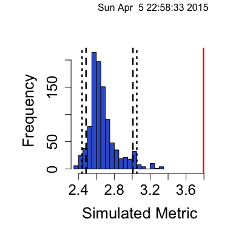

```r
plot(myModel,type = "hist")
```

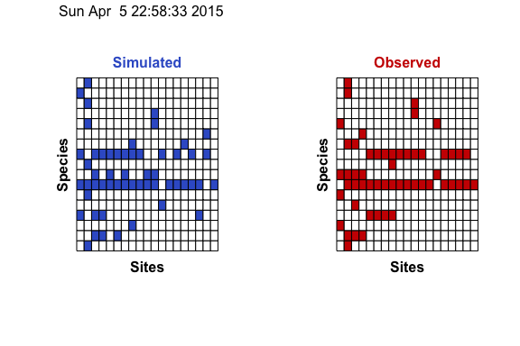

```r
plot(myModel,type = "cooc")
```

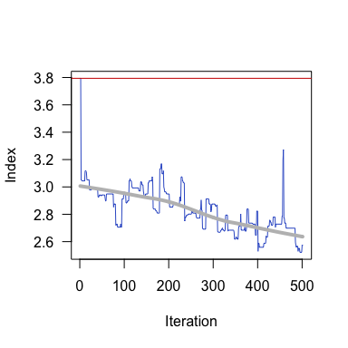

```r
plot(myModel,type = "burn_in")
```

```r
# create a model with sim10 and user-supplied species and site weights
myModel <- cooc_null_model(speciesData=dataWiFinches,algo="sim10",
                           suppressProg=TRUE,algoOpts=list(rowWeights
                           =(1:17),colWeights=(1:19)))
summary(myModel)
```

[output not shown]

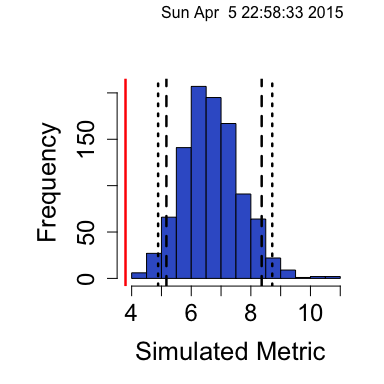

```r
plot(myModel,type="hist")
```

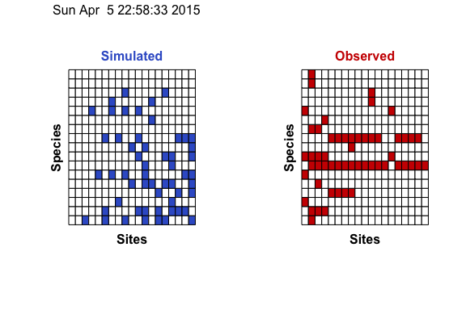

```r
plot(myModel,type="cooc")
```

## Caveats

`sim9` used with the `c_score` has been tested repeatedly and has satisfactory performance with most kinds of random matrices (= low Type I errors). However, the C-score is an average across hundreds or even thousands of unique species pairs. Highly non-random matrices will always have a mixture of aggregated, random, or segregated species pairs. In future versions of EcoSimR, we hope to provide algorithms for Werner Ulrich’s [PAIRS](http://www.keib.umk.pl/pairs/?lang=en) program, which uses an empirical Bayes approach to test all individual species pairs and screen for false positives (see Gotelli and Ulrich 2010 for details).

Although co-occurrence analyses arose from the controversy over assembly rules and interspecific competition, these null model analyses can only establish that a matrix or species pair is significantly aggregated or segregated. The causes of such segregation can include species interactions, habitat assocations, and dispersal limitations. Bloise et al. (2014) use additional data layers (geo-referenced sites and measures of environmental conditions in each site) to construct a logic tree with 9 possible branch tips for interpreting the outcomes of species co-occurrence analyses.

## Literature

Blois, J.L., N.J. Gotelli, A.K. Behrensmeyer, J.T. Faith, S.K. Lyons, J.W. Williams, K.L. Amatangelo, A. Bercovici, A. Du, J.T. Eronen, G.R. Graves, N. Jud, C. Labandeira, C.V. Looy, B. McGill, D. Patterson, R. Potts, B. Riddle, R. Terry, A. Toth, A. Villasenor, and S. Wing. 2014. A framework for evaluating the influence of climate, dispersal limitation, and biotic interactions using fossil pollen associations across the late Quaternary. Ecography 37:1095-1108.

Connor, E.F. and D. Simberloff. 1979. The assembly of species communities: chance or competition? Ecology 60: 1132-1140.

Connor, E.F., M.D. Collins, and D. Simberloff. 2013. The checkered history of checkerboard distributions. Ecology 94: 2403-2414

Diamond, J.M. 1975. Assembly of species communities. p. 342-444 in: Ecology and Evolution of Communities. M.L. Cody and J.M. Diamond (eds.). Harvard University Press, Cambridge.

Gotelli, N.J. 2000. Null model analysis of species co-occurrence patterns. Ecology 81: 2606-2621.

Gotelli, N.J. and L.G. Abele. 1982. Statistical distributions of West Indian land bird families. Journal of Biogeography 9: 421-435.

Gotelli, N.J. and W. Ulrich. 2010. The empirical Bayes approach as a tool to identify non-random species associations. Oecologia 162:463-477.

Gotelli, N.J., G.R. Graves, and C. Rahbek. 2010. Macroecological signals of species interactions in the Danish avifauna. Proceedings of the National Academy of Sciences, U.S.A. 107: 530-535.

Jenkins, D.G. 2006. In search of quorum effects in metacommunity structure: species co-occurrence analyses. Ecology 87:1523-1531

Sanderson, J.G., J.M. Diamond, and S.L. Pimm. 2010. Pairwise co-existence of Bismarck and Solomon landbird species. Evolutionary Ecology Research pp. 771-786

Schluter, D. 1984. A variance test for detecting species associations, with some example applications. Ecology 65: 998-1005.

Stone. L. and A. Roberts. 1990. The checkerboard score and species distributions. Oecologia 85: 74-79.

Strona. G., D. Nappo, F. Boccacci, S. Fattorini, and J. San-Miguel-Ayanz. 2014. A fast and unbiased procedure to randomize ecological binary matrices with fixed row and column totals. Nature Communications 5:4114 | DOI: 10.1038/ncomms5114.

[^1]: Unlike all of the other algorithms so far introduced into EcoSimR, `sim9` is a Markov chain, in which each algorithm is derived by altering the one before it in a sequence. To eliminate transient behavior as the simulated algorithms move away from the original matrix, `sim9` allows you to specify a burn-in period and lets you inspect the trace of the index during the burn-in. It is not a trivial computational problem to draw a random matrix from the large set of all possible matrices with fixed row and column sums. The original Connor and Simberloff (1979) method was to randomly draw two rows and two columns, swap the elements if they formed a checkerboard unit, and replace them to create a new matrix. This method gives acceptable results, but it is slow and introduces a small bias by only retaining solutions that can be swapped. The version we have implemented in EcoSimR draws two random rows to create a sub-matrix, reshuffles all of the columns in the submatrix that can be swapped, and then replaces it. This is much more efficient, eliminates the bias in the original swap, and requires a shorter burn-in to achieve stationarity. Strona et al. (2014) recently described this as the “Curveball algorithm”. Especially for large matrices (> 100 x 100), there is still substantial autocorrelation in the sequential matrices, and future versions of EcoSimR will contain a thinning option to select a subset of the sequential matrices. See more details in the `sim9` documentation.